# DO Superovulation Genetic Mapping

DMG

10/18/2022

## Introduction

I received phenotype and genotype data for 300 female DO mice. Oocytes were extracted after super-ovulation and were counted and categorized, fertilized with C57BL/6J sperm, and counted and categorized again. The goal of the project is to identify genes which influence the number of oocytes produced, oocyte viability, and the proportion of oocytes which go on to be fertilized.

## Data Wrangling

Most of the data was previously gathered. Here, we need to subset the samples to retain samples which occur in all data sets.

```r
common_samples = intersect(rownames(pheno), colnames(norm_expr))

pheno    = pheno[common_samples,]
pheno_rz = pheno_rz[common_samples,]
covar    = covar[common_samples,]
probs    = probs[common_samples,]
K        = lapply(K, function(z) { z[common_samples, common_samples] })
rna      = rna[common_samples,]

common_genes = intersect(rownames(norm_expr), rownames(annot))
norm_expr    = norm_expr[,common_samples]
```

There are 294 mice in the final, intersected data set.

There are two general covariates that I could use: generation or date of isolation. I regressed each phenotype on generation or date. Generation and date are confounded, so I didn’t put them in the same model.

```r
df = data.frame(pheno) %>%
       rownames_to_column(var = 'mouse') %>%
       left_join(select(covar, mouse, sex, gen, date)) %>%
       pivot_longer(cols = Weight:DAY2NumbFrag, names_to = 'phenotype', values_to = 'value') %>%
       group_by(phenotype) %>%
       nest()
```

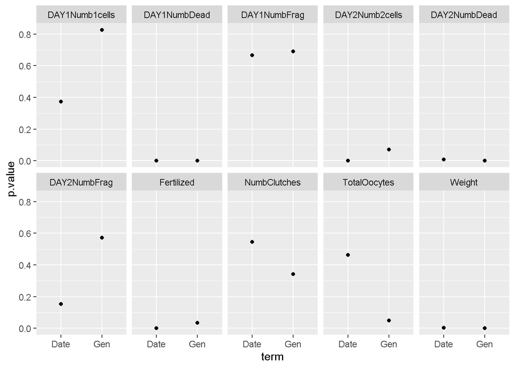

```r
df_gen = df %>%
  mutate(mod  = map(data, ~ aov(lm(.x$value ~ .x$gen))),
         mod_summ = map(mod, tidy)) %>%
  select(-data, -mod) %>%
  unnest(cols = mod_summ) %>%
  select(-sumsq, -meansq) %>%
  filter(!is.na(statistic))

df_date = df %>%
  mutate(mod  = map(data, ~ aov(lm(.x$value ~ .x$date))),
         mod_summ = map(mod, tidy)) %>%
  select(-data, -mod) %>%
  unnest(cols = mod_summ) %>%
  select(-sumsq, -meansq) %>%
  filter(!is.na(statistic))

rm(df)

bind_rows(df_gen, df_date) %>%
  mutate(term = str_replace(term, '^\\.x\\$',''),
         term = str_to_title(term)) %>%
  ggplot(aes(term, p.value)) +
    geom_point() +
    facet_wrap(~phenotype, nrow = 2)
```

Generation has a better fit for two phenotypes and date has a better fit for two models. The other phenotypes are largely the same. Date has six levels and so consumes 5 degrees of freedom in the models.

## Heritability

Estimate the heritability of each phenotype. We may have polygenic traits that are heritable, but don’t have strong QTL.

```r
herit = data.frame(phenotype = colnames(pheno),
                   herit     = 0)
K_all = calc_kinship(probs, type = 'overall')

for(i in 1:ncol(pheno)) {

  pheno_name = colnames(pheno)[i]
  ph = pheno[,pheno_name, drop = FALSE]

  meta_row  = which(meta$column == pheno_name)
  transform = meta$transform[meta_row]

  if(!is.na(transform)) {
    if(transform == 'log') {
      ph[,1] = log(ph[,1])
    } else if(transform == 'log1p') {
      ph[,1] = log1p(ph[,1])
    } else if(transform == 'sqrt') {
      ph[,1] = sqrt(ph[,1])
    }
  } # if(!is.na(transform))

  covar_names = strsplit(meta$covar[meta_row], split = ';')[[1]]
  addcovar    = model.matrix(~ ., data = covar[,covar_names, drop = FALSE])[,-1, drop = FALSE]

  h = est_herit(pheno = ph, kinship = K_all, addcovar = addcovar)
  herit$herit[i] = h

} # for(i)

herit
```

```
##         phenotype     herit
## 1          Weight 0.3744080
## 2    NumbClutches 0.2339670
## 3  DAY1Numb1cells 0.3922262
## 4    DAY1NumbDead 0.5721054
## 5    DAY1NumbFrag 0.0000000
## 6    TotalOocytes 0.3639666
## 7  DAY2Numb2cells 0.4003637
## 8      Fertilized 0.4766109
## 9    DAY2NumbDead 0.1824465
## 10   DAY2NumbFrag 0.1865992
```

## QTL Results

### Body Weight

Heritability: 0.37

Gather phenotype and covariates.

```r
pheno_name = 'Weight'
ph = pheno[,pheno_name, drop = FALSE]

meta_row  = which(meta$column == pheno_name)
transform = meta$transform[meta_row]

if(transform == 'log') {
  ph[,1] = log(ph[,1])
} else if(transform == 'log1p') {
  ph[,1] = log1p(ph[,1])
} else if(transform == sqrt) {
  ph[,1] = sqrt(ph[,1])
}

covar_names = strsplit(meta$covar[meta_row], split = ';')[[1]]
addcovar    = model.matrix(~ ., data = covar[,covar_names, drop = FALSE])[,-1, drop = FALSE]
```

Map phenotype with gen as covariates.

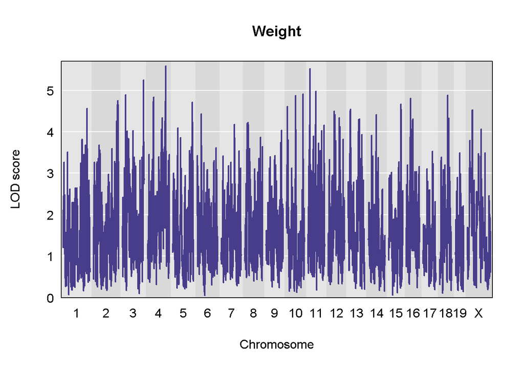

```r
qtl = scan1(genoprobs = probs,
            pheno     = ph,
            kinship   = K,
            addcovar  = addcovar)
plot(qtl, map, main = pheno_name)
```

Map rankZ-transformed phenotype.

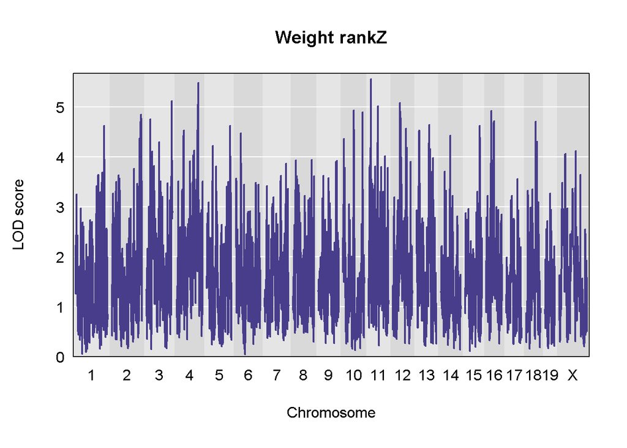

```r
ph  = pheno_rz[,pheno_name, drop = FALSE]
qtl = scan1(genoprobs = probs,
            pheno     = ph,
            kinship   = K,
            addcovar  = addcovar)
plot(qtl, map, main = paste(pheno_name, 'rankZ'))
```

There are no peaks with sufficiently high LOD scores to pursue.

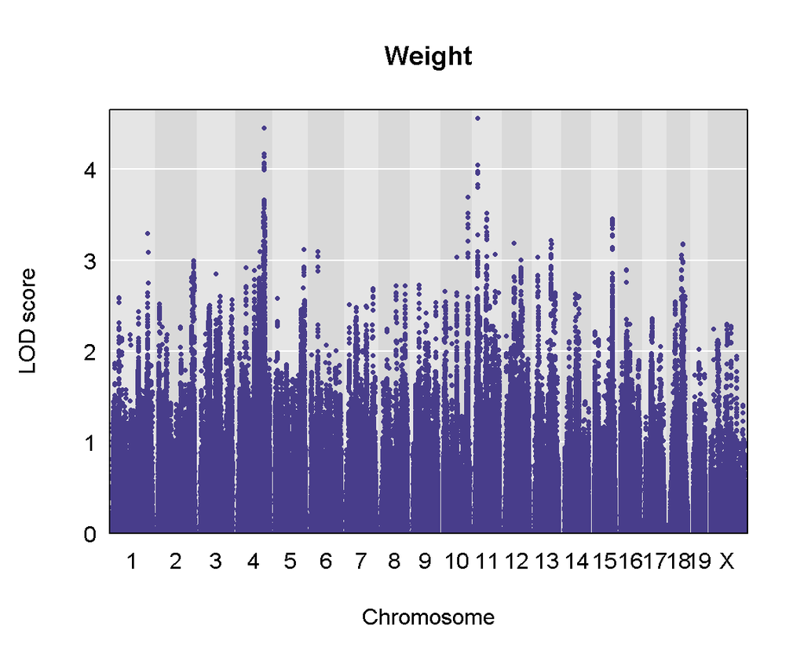

```r
gwas = scan1snps(genoprobs = probs, map = map, pheno = ph, kinship = K, addcovar = addcovar,
                 query_func = snp_fxn, keep_all_snps = FALSE)
plot_snpasso(gwas$lod, gwas$snpinfo, main = pheno_name)
```

### Number of Clutches

Heritability: 0.23

This phenotype is ordinal, with values of 0, 1, or 2. Only 6 out of 294 mice have values below 2.

Gather phenotype and covariates.

```r
pheno_name = 'NumbClutches'
ph = pheno[,pheno_name, drop = FALSE]

meta_row  = which(meta$column == pheno_name)
transform = meta$transform[meta_row]

if(!is.na(transform)) {
  if(transform == 'log') {
    ph[,1] = log(ph[,1])
  } else if(transform == 'log1p') {
    ph[,1] = log1p(ph[,1])
  } else if(transform == sqrt) {
    ph[,1] = sqrt(ph[,1])
  }
} # if(!is.na(transform))

covar_names = strsplit(meta$covar[meta_row], split = ';')[[1]]
addcovar    = model.matrix(~ ., data = covar[,covar_names, drop = FALSE])[,-1, drop = FALSE]
```

Map phenotype with date as covariates.

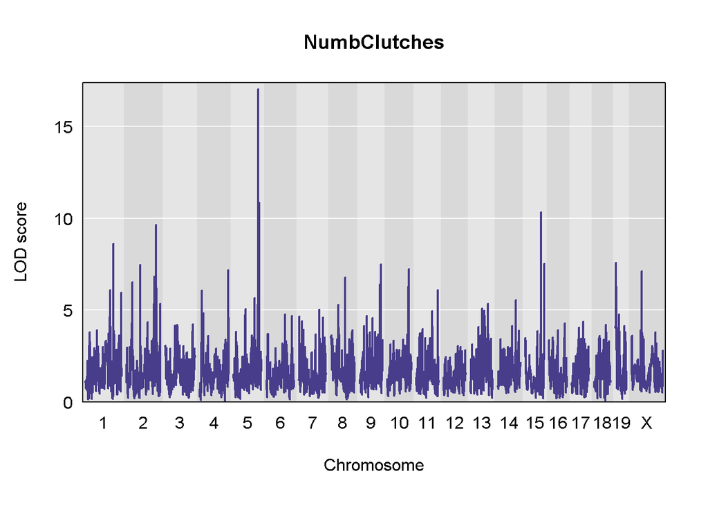

```r
qtl = scan1(genoprobs = probs,
            pheno     = ph,
            kinship   = K,
            addcovar  = addcovar)
plot(qtl, map, main = pheno_name)
```

What does the Chr 5 peak look like when I zoom in?

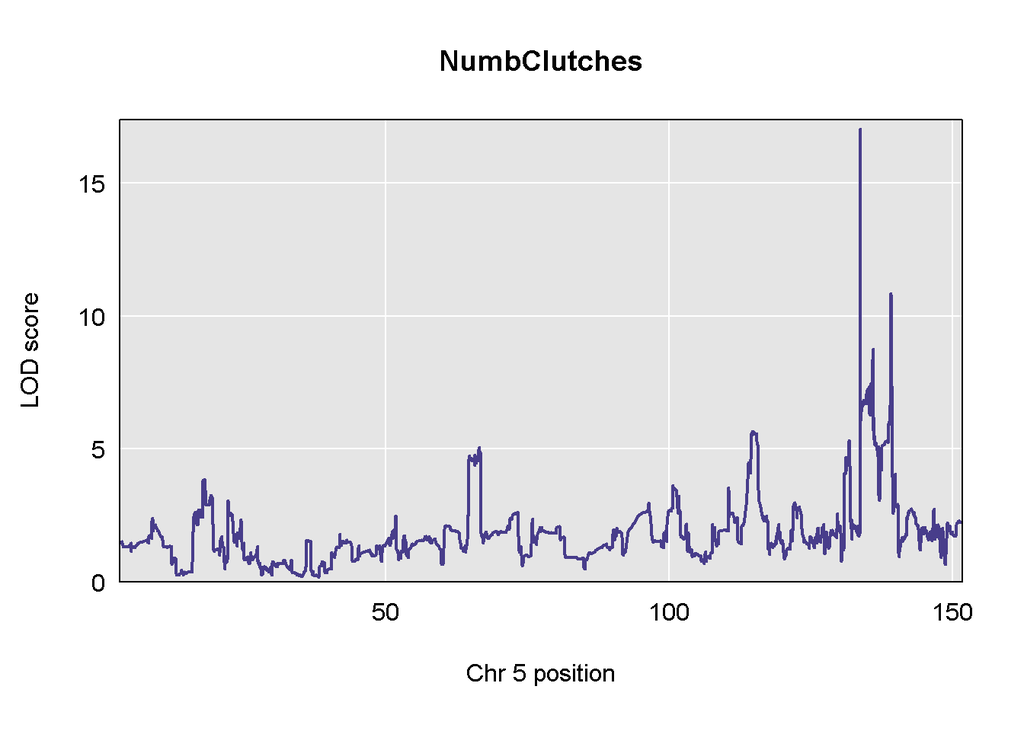

```r
plot(qtl, map, main = pheno_name, chr = '5')
```

The peak looks spikey. It may be due to the distribution of the phenotype.

Run 10 permutations just to get a sense of whether the observed LOD scores might be significant.

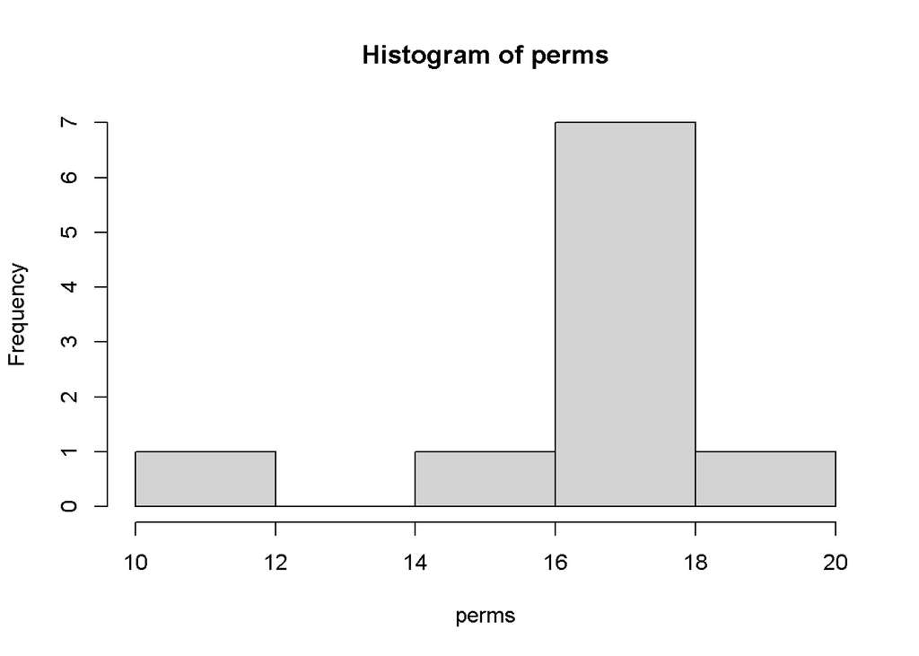

```r
perms = qtl = scan1perm(genoprobs = probs,
            pheno     = ph,
            kinship   = K,
            addcovar  = addcovar, n_perm = 10)
hist(perms)
```

The median LOD across permutations is as higher than 15, so I don’t think that these QTL are significant.

Since NumbClutches is a very skewed phenotype, I expect the LOD scores to be skewed as well.

I’m concerned the the low number of mice with less than two clutches makes this an unreliable phenotype.

### Day 1 Number of 1-cells

Heritability: 0.39

Gather phenotype and covariates.

```r
pheno_name = 'DAY1Numb1cells'
ph = pheno[,pheno_name, drop = FALSE]

meta_row  = which(meta$column == pheno_name)
transform = meta$transform[meta_row]

if(transform == 'log') {
  ph[,1] = log(ph[,1])
} else if(transform == 'log1p') {
  ph[,1] = log1p(ph[,1])
} else if(transform == sqrt) {
  ph[,1] = sqrt(ph[,1])
}

covar_names = strsplit(meta$covar[meta_row], split = ';')[[1]]
addcovar    = model.matrix(~ ., data = covar[,covar_names, drop = FALSE])[,-1, drop = FALSE]
```

Map phenotype with date,TotalOocytes as covariates.

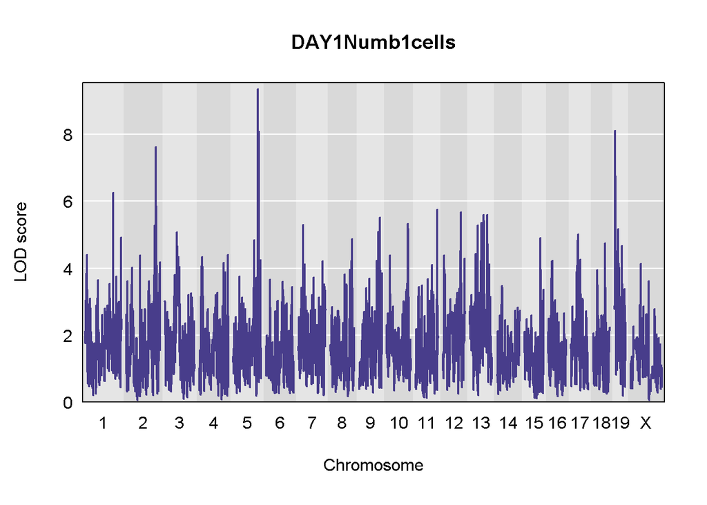

```r
qtl = scan1(genoprobs = probs,
            pheno     = ph,
            kinship   = K,
            addcovar  = addcovar)
plot(qtl, map, main = pheno_name)
```

This phenotype has a LOD profile similar to NumbClutches. I’m mapping with total oocytes as a covariate, which should have accounted for this.

Plot the LOD on the chromosomes with LOD over 7.

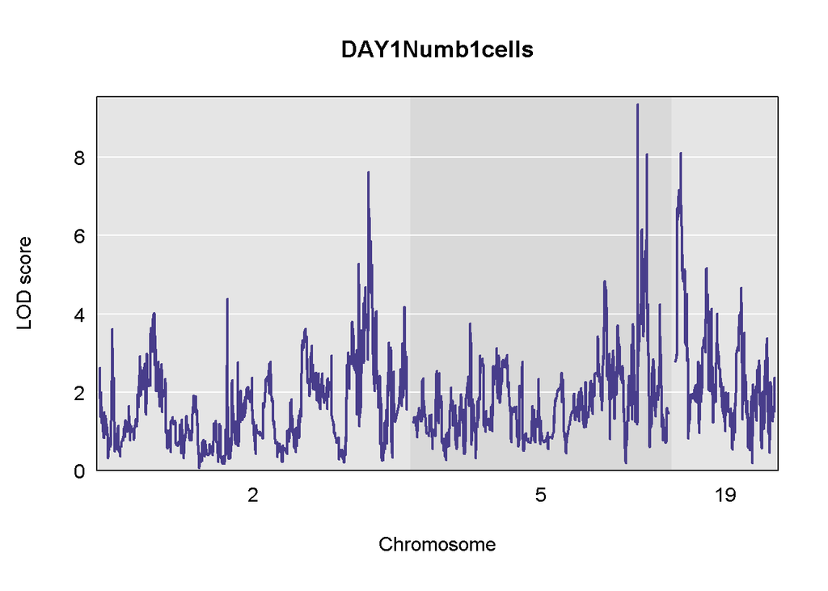

```r
plot(qtl, map, main = pheno_name, chr = c(2, 5, 19))
```

The peaks look spikey.

Plot the phenotype by genotype plot for the Chr 5 locus and see if any one founder seems to be associated with the phenotype. I’m looking for one founder to be homozygous for the lowest values and possibly some of the same founder’s hets to be low as well. If there are random genotypes associated with the low values, then I’m not confident that this is a real genetic signal.

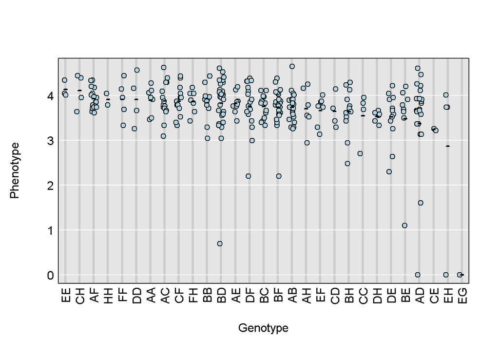

```r
chr = '5'
peaks = find_peaks(qtl, map, threshold = 8)
peaks = peaks[peaks$chr == chr,]

mkr = find_marker(map, chr = chr, pos = peaks$pos[1])

# Read in 36 state genoprobs and fix sample names.
pr36 = readRDS(file.path(data_dir, 'bolcun-filas1__GigaMUGA_genoprobs_36state.rds'))
for(i in seq_along(pr36)) {
  rownames(pr36[[i]]) = gsub('^Jackson_Lab_Filas_MURGIGV01_20220929_|(_T)?_[A-H][0-9]+$', '', rownames(pr36[[i]]))
  rownames(pr36[[i]]) = gsub('^DO_QTL_T ', 'SO', rownames(pr36[[i]]))
  rownames(pr36[[i]]) = sub('SO', 'SODO', rownames(pr36[[i]]))

} # for(i)

# Get maximum marginal genotype at Chr 5 marker.
gt  = maxmarg(probs = pr36[,chr], minprob = 0.01)
gt  = gt[[1]][rownames(ph), mkr]
gt = setNames(colnames(pr36[[1]])[gt], names(gt))

plot_pxg(geno = gt, pheno = ph)
```

```r
rm(pr36)
```

The phenotype distribution is also skewed.

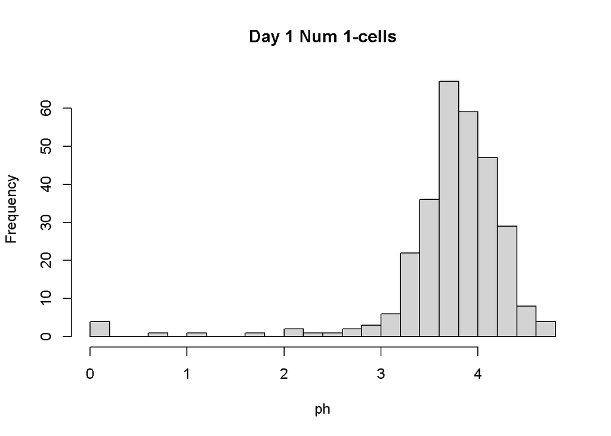

```r
hist(ph, breaks = 20, main = 'Day 1 Num 1-cells')
```

Map Day 1 1-cells with total oocytes and number of clutches as a covariate.

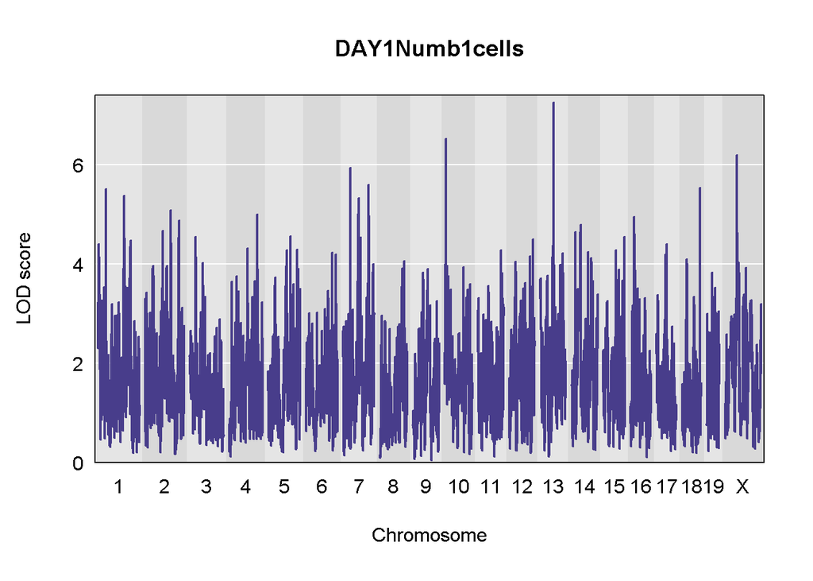

```r
addcovar = cbind(addcovar, covar$NumbClutches)[,-1]

qtl = scan1(genoprobs = probs,
            pheno     = ph,
            kinship   = K,
            addcovar  = addcovar)
plot(qtl, map, main = pheno_name)
```

Map Day 1 1-cells with total oocytes and with mice that have less than two clutches removed.

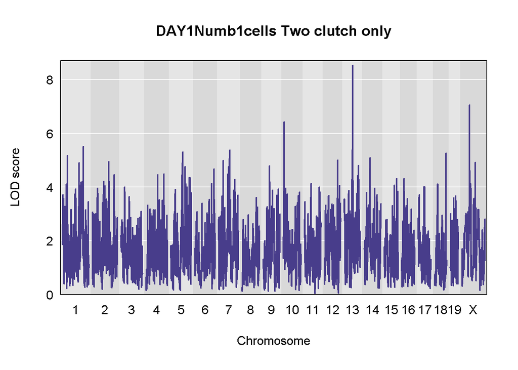

```r
addcovar = model.matrix(~ ., data = covar[,covar_names, drop = FALSE])[,-1, drop = FALSE]
samples  = rownames(covar)[covar$NumbClutches == 2]

qtl = scan1(genoprobs = probs[samples,],
            pheno     = ph[samples,, drop = FALSE],
            kinship   = K,
            addcovar  = addcovar[samples,,drop = FALSE])
plot(qtl, map, main = paste(pheno_name, 'Two clutch only'))
```

Map rankZ-transformed phenotype with date and total oocytes as covariates. Remove samples with less than two clutches.

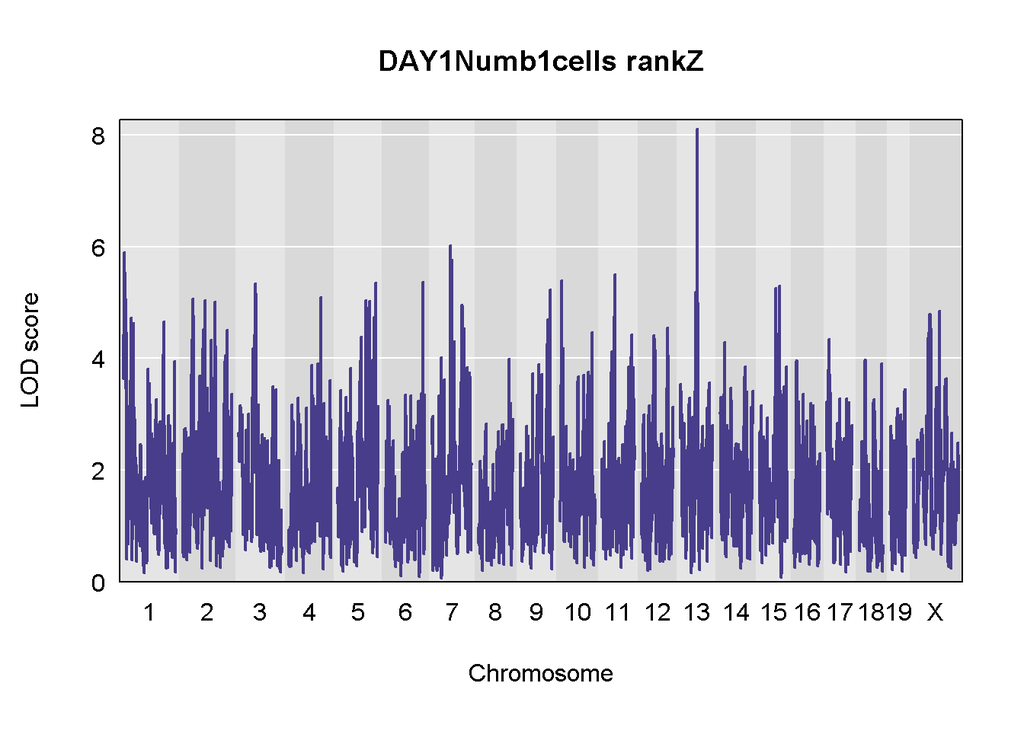

```r
addcovar    = model.matrix(~ ., data = covar[samples,covar_names, drop = FALSE])[,-1, drop = FALSE]
ph  = pheno_rz[samples,pheno_name, drop = FALSE]
qtl = scan1(genoprobs = probs[samples,],
            pheno     = ph[samples,,drop = FALSE],
            kinship   = K,
            addcovar  = addcovar[samples,,drop = FALSE])
plot(qtl, map, main = paste(pheno_name, 'rankZ'))
```

Plot the peak on chr 13.

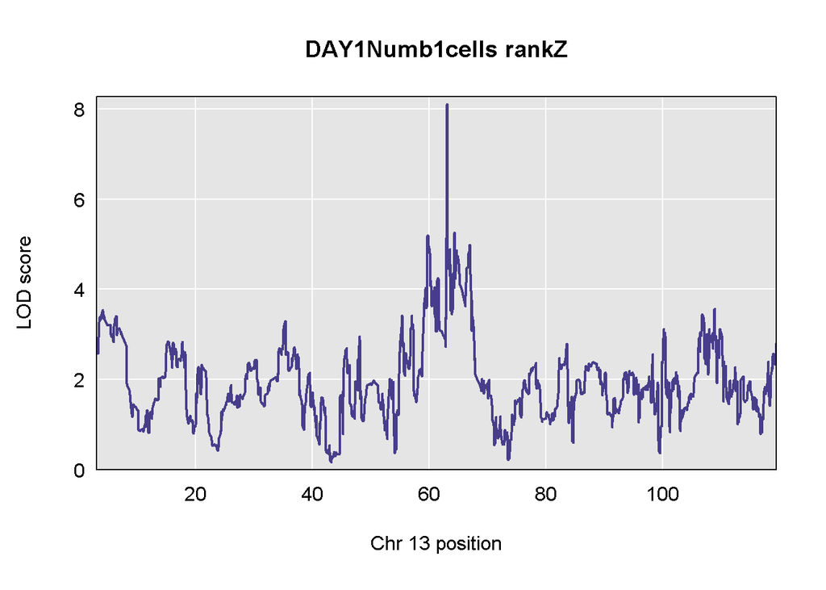

```r
plot(qtl, map, main = paste(pheno_name, 'rankZ'), chr = '13')
```

```r
peaks = find_peaks(qtl, map, threshold = 7)
```

This peak lstill ooks spikey. But it may be a small recombination block.

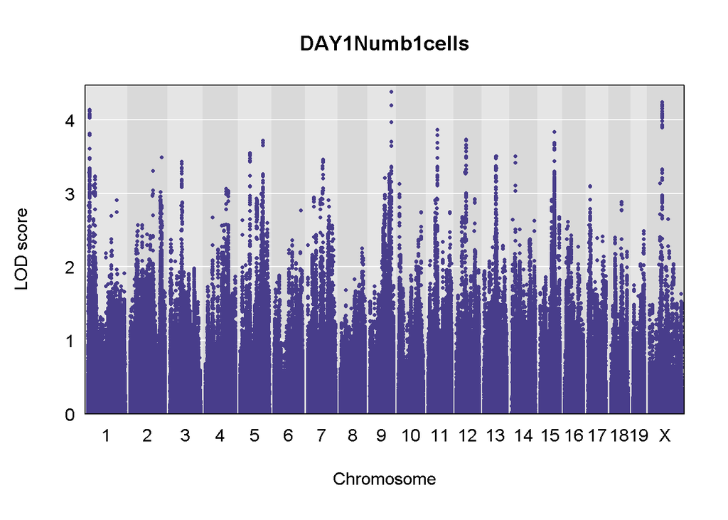

```r
gwas = scan1snps(genoprobs = probs[samples,], map = map, pheno = ph[samples,,drop = FALSE],
                 kinship = K, addcovar = addcovar[samples,,drop = FALSE],
                 query_func = snp_fxn, keep_all_snps = FALSE)
plot_snpasso(gwas$lod, gwas$snpinfo, main = pheno_name)
```

Plot the founder allele effects on Chr 13.

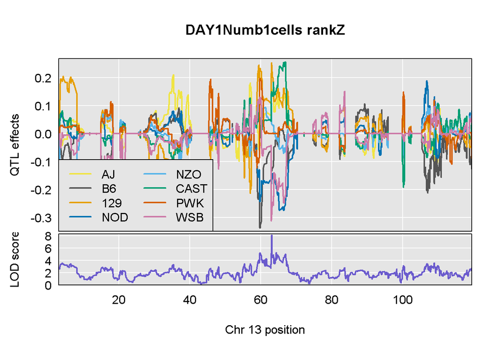

```r
chr = '13'
feff = scan1blup(genoprobs = probs[samples,chr],
                 pheno     = ph[samples,,drop = FALSE],
                 kinship   = K[[chr]],
                 addcovar  = addcovar[samples,,drop = FALSE])

plot_coefCC(feff, map, scan1_output = qtl, main = paste(pheno_name, 'rankZ'),
            legend = 'bottomleft')
```

Run mediation analysis on the Chr 13 peak.

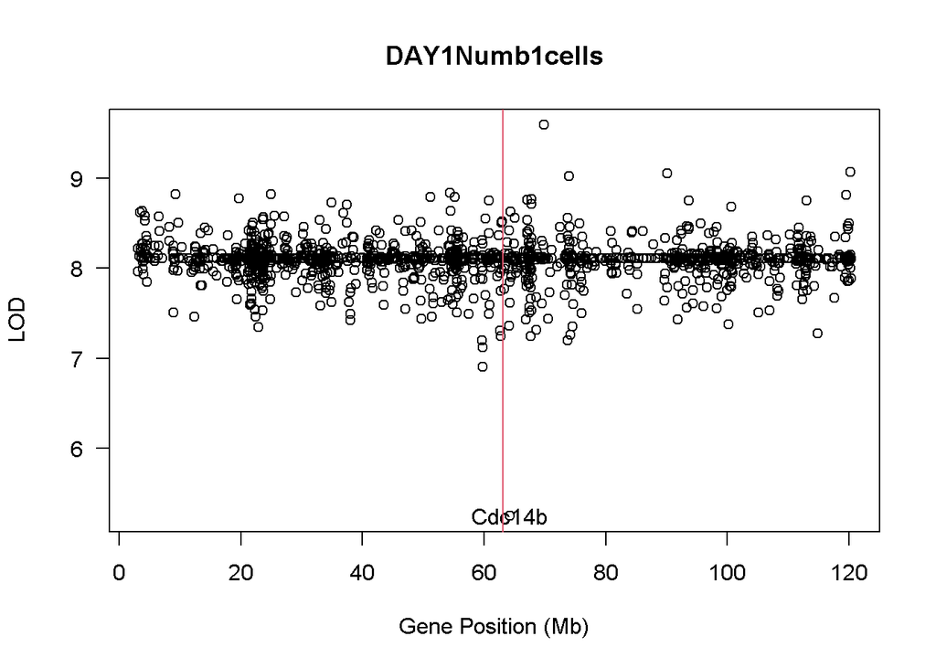

```r
med = mediation(pheno = ph[samples,,drop = FALSE], covar = addcovar[samples,,drop = FALSE],
                probs = probs[samples,], K = K, map = map, expr = norm_expr, annot = annot, chr = chr)
plot(med_lod ~ pos, data = med, las = 1, main = pheno_name,
     xlab = 'Gene Position (Mb)', ylab = 'LOD')
wh = which(med$med_lod < 6)
text(med$pos[wh], med$med_lod[wh], labels = med$symbol[wh])
abline(v = peaks$pos, col = 2)
```

*Cdc14b* on Alliance for Genome Resources: https://www.alliancegenome.org/gene/MGI:2441808

“Predicted to enable protein serine/threonine phosphatase activity and protein tyrosine phosphatase activity. Predicted to be involved in cilium assembly; microtubule cytoskeleton organization; and regulation of cell cycle process. Predicted to act upstream of or within DNA repair. Predicted to be located in nucleoplasm. Predicted to be active in cytoplasm; microtubule cytoskeleton; and nucleolus. Is expressed in embryo. Orthologous to several human genes including CDC14B (cell division cycle 14B).”

“PHENOTYPE: Mice homozygous for a knock-out allele exhibit premature aging, including premature cataracts and kyphosis; reduced fertility, particularly in female mice;”

Perform association mapping in the QTL interval on Chr 13.

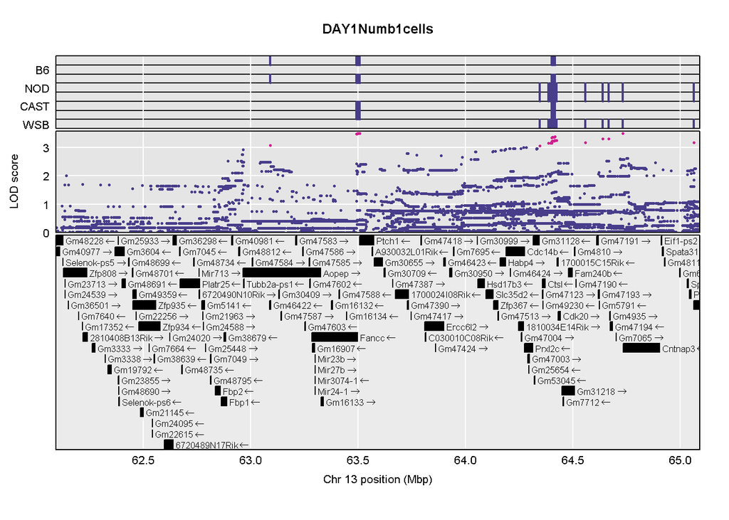

```r
peaks = find_peaks(qtl, map)
peaks = peaks[peaks$chr == chr,]
start = peaks$pos - 1
end   = peaks$pos + 2

assoc = scan1snps(genoprobs = probs[samples,chr], map = map, pheno = ph[samples,, drop = FALSE],
                  kinship = K[[chr]], addcovar = addcovar[samples,,drop = FALSE],
                  query_func = snp_fxn, chr = chr, start = start,
                  end = end, keep_all_snps = TRUE)

g = gene_fxn(chr, start, end)
plot_snpasso(assoc$lod, assoc$snpinfo, drop_hilit = 0.5, genes = g, sdp_panel = TRUE,
             panel_prop = c(0.25, 0.2, 0.55), colors = 'black', main = pheno_name)
```

Get the SNPs with the highest LOD scores and intersect them with Ensembl regulatory regions.

```r
ts = top_snps(assoc$lod, assoc$snpinfo, drop = 0.5)
ts = GRanges(seqnames = ts$chr, ranges = IRanges(start = ts$pos * 1e6, width = 1),
             mcols = ts[,-c(2:3,5,16:19)])
colnames(mcols(ts)) =sub('^mcols\\.', '', colnames(mcols(ts)))

a = listAttributes(mart)
f = listFilters(mart)

bm = getBM(attributes = a$name, filters = c('chromosome_name', 'start', 'end'),
           values = list(chromosome_name = '13', start = 64250000, end = 64500000),
           mart = mart)

bm = GRanges(seqnames = bm$chromosome_name, ranges = IRanges(start = bm$chromosome_start, end = bm$chromosome_end), mcols = bm[,-c(1, 5:7, 9, 11:14)])
colnames(mcols(bm)) =sub('^mcols\\.', '', colnames(mcols(bm)))

ol = findOverlaps(bm, ts)

ol = cbind(as.data.frame(ts[subjectHits(ol)]),
           as.data.frame(bm[queryHits(ol)]))

table(ol$feature_type_name)
```

```
##
##                 Enhancer Promoter Flanking Region
##                      320                     1360
```

There some SNPs that intersect with and enhancer. Which onces are these?

```r
unique(subset(ol[,c(1:27)], feature_type_name == 'Enhancer'))
```

```
##      seqnames    start      end width strand      snp_id alleles ensembl_gene
## 1361       13 64417241 64417241     1      *  rs33883306     C|T
## 1362       13 64417562 64417562     1      * rs231975427     T|C
## 1363       13 64417733 64417733     1      * rs211809049     G|A
## 1601       13 64421398 64421398     1      *  rs33883153     A|G
##             consequence A_J C57BL_6J X129S1_SvImJ NOD_ShiLtJ NZO_HlLtJ CAST_EiJ
## 1361 intergenic_variant   1        1            1          2         2        1
## 1362 intergenic_variant   1        1            1          2         2        1
## 1363 intergenic_variant   1        1            1          2         2        1
## 1601 intergenic_variant   1        1            1          2         2        1
##      PWK_PhJ WSB_EiJ      lod seqnames.1  start.1    end.1 width.1 strand.1
## 1361       1       2 3.242045         13 64416801 64417800    1000        *
## 1362       1       2 3.242045         13 64416801 64417800    1000        *
## 1363       1       2 3.242045         13 64416801 64417800    1000        *
## 1601       1       2 3.242114         13 64421201 64423200    2000        *
##      regulatory_stable_id bound_seq_region_start bound_seq_region_end
## 1361   ENSMUSR00000076035               64416801             64417800
## 1362   ENSMUSR00000076035               64416801             64417800
## 1363   ENSMUSR00000076035               64416801             64417800
## 1601   ENSMUSR00000549486               64421201             64423200
##      feature_type_name
## 1361          Enhancer
## 1362          Enhancer
## 1363          Enhancer
## 1601          Enhancer
```

### Day 1 Number of Dead 1-cells

Gather phenotype and covariates.

```r
pheno_name = 'DAY1NumbDead'
ph = pheno[,pheno_name, drop = FALSE]

meta_row  = which(meta$column == pheno_name)
transform = meta$transform[meta_row]

if(transform == 'log') {
  ph[,1] = log(ph[,1])
} else if(transform == 'log1p') {
  ph[,1] = log1p(ph[,1])
} else if(transform == 'sqrt') {
  ph[,1] = sqrt(ph[,1])
}

covar_names = strsplit(meta$covar[meta_row], split = ';')[[1]]
addcovar    = model.matrix(~ ., data = covar[,covar_names, drop = FALSE])[,-1, drop = FALSE]
```

Map phenotype with date,TotalOocytes as covariates.

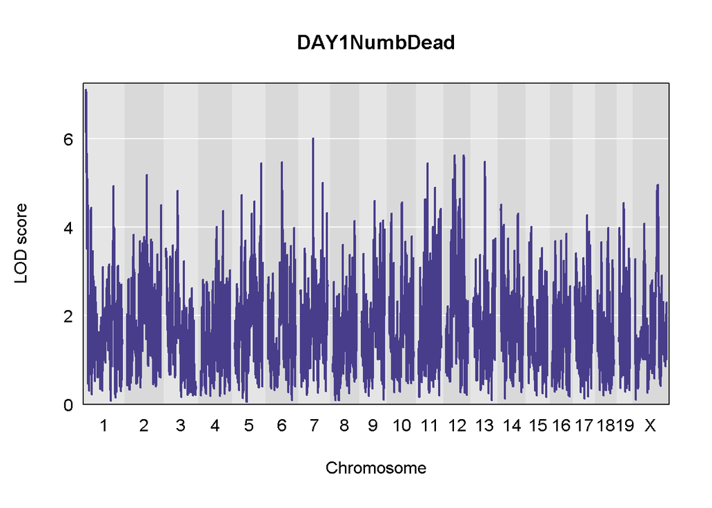

```r
qtl = scan1(genoprobs = probs,
            pheno     = ph,
            kinship   = K,
            addcovar  = addcovar)
plot(qtl, map, main = pheno_name)
```

Map rankZ-transformed phenotype.

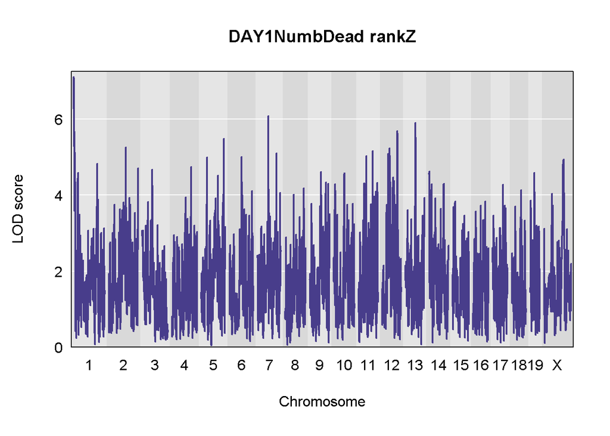

```r
ph  = pheno_rz[,pheno_name, drop = FALSE]
qtl = scan1(genoprobs = probs,
            pheno     = ph,
            kinship   = K,
            addcovar  = addcovar)
plot(qtl, map, main = paste(pheno_name, 'rankZ'))
```

Plot the founder allele effects on Chr 1.

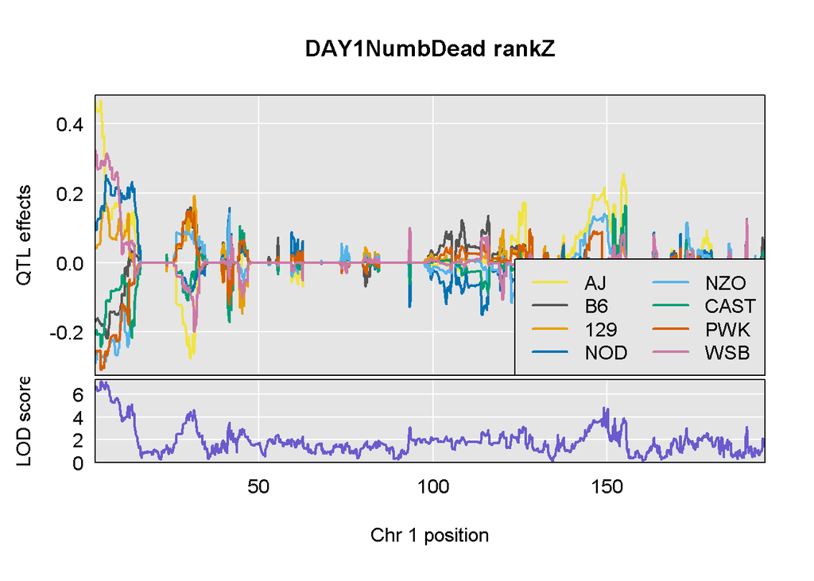

```r
chr = '1'
feff = scan1blup(genoprobs = probs[,chr],
                 pheno     = ph,
                 kinship   = K[[chr]],
                 addcovar  = addcovar)
plot_coefCC(feff, map, scan1_output = qtl, main = paste(pheno_name, 'rankZ'),
            legend = 'bottomright')
```

Perform association mapping in the QTL interval on Chr 1.

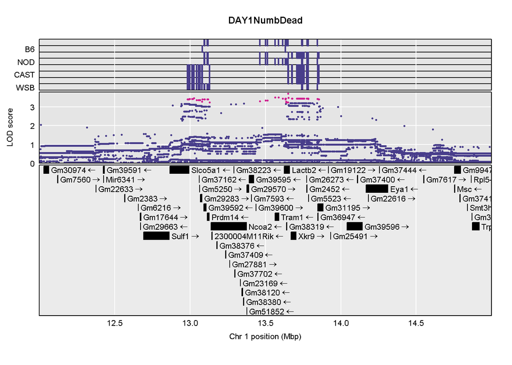

```r
peaks = find_peaks(qtl, map)
peaks = peaks[peaks$chr == chr,]
start = 12
end   = 15

assoc = scan1snps(genoprobs = probs[samples,chr], map = map, pheno = ph[samples,,drop = FALSE],
                  kinship = K[[chr]], addcovar = addcovar[samples,,drop = FALSE],
                  query_func = snp_fxn, chr = chr, start = start,
                  end = end, keep_all_snps = TRUE)

g = gene_fxn(chr, start, end)
plot_snpasso(assoc$lod, assoc$snpinfo, drop_hilit = 0.5, genes = g, sdp_panel = TRUE,
             panel_prop = c(0.25, 0.2, 0.55), colors = 'black', main = pheno_name)
```

The linkage peaks was closer to 4.5 Mb, but the association mapping peaks is near 13.5 Mb.

Get the SNPs with the highest LOD scores and retain those with missense, splice or stop variants.

```r
ts = top_snps(assoc$lod, assoc$snpinfo, drop = 0.5)
ts = ts[grep('missense|splice|stop', ts$consequence),]
ts
```

```
##  [1] snp_id       chr          pos          alleles      sdp
##  [6] ensembl_gene consequence  A_J          C57BL_6J     129S1_SvImJ
## [11] NOD_ShiLtJ   NZO_HlLtJ    CAST_EiJ     PWK_PhJ      WSB_EiJ
## [16] type         index        interval     on_map       lod
## <0 rows> (or 0-length row.names)
```

There are no coding variants among the top SNPs. I can’t tell if there is anything interesting under this peak.

Run mediation analysis on the Chr 1 peak.

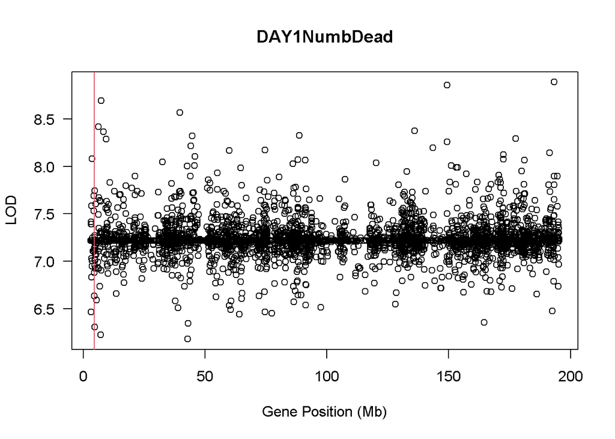

```r
med = mediation(pheno = ph[samples,,drop = FALSE], covar = addcovar[samples,,drop = FALSE],
                probs = probs[samples,], K = K, map = map, expr = norm_expr, annot = annot, chr = chr)
plot(med_lod ~ pos, data = med, las = 1, main = pheno_name,
     xlab = 'Gene Position (Mb)', ylab = 'LOD')
wh = which(med$med_lod < 6)
if(length(wh > 0)) {
  text(med$pos[wh], med$med_lod[wh], labels = med$symbol[wh])
}
abline(v = peaks$pos, col = 2)
```

I don’t see any genes that look significant in the mediation analysis.

### Day 1 Number of Fragmented 1-cells

Heritability: 0

Gather phenotype and covariates.

```r
pheno_name = 'DAY1NumbFrag'
ph = pheno[,pheno_name, drop = FALSE]

meta_row  = which(meta$column == pheno_name)
transform = meta$transform[meta_row]

if(transform == 'log') {
  ph[,1] = log(ph[,1])
} else if(transform == 'log1p') {
  ph[,1] = log1p(ph[,1])
} else if(transform == 'sqrt') {
  ph[,1] = sqrt(ph[,1])
}

covar_names = strsplit(meta$covar[meta_row], split = ';')[[1]]
addcovar    = model.matrix(~ ., data = covar[,covar_names, drop = FALSE])[,-1, drop = FALSE]
```

Map phenotype with date,TotalOocytes as covariates.

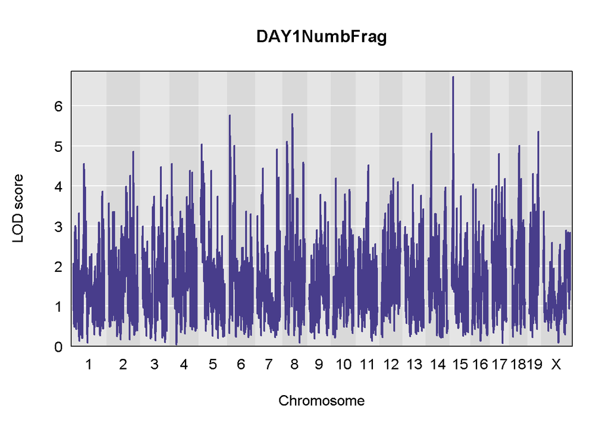

```r
qtl = scan1(genoprobs = probs,
            pheno     = ph,
            kinship   = K,
            addcovar  = addcovar)
plot(qtl, map, main = pheno_name)
```

Map rankZ-transformed phenotype.

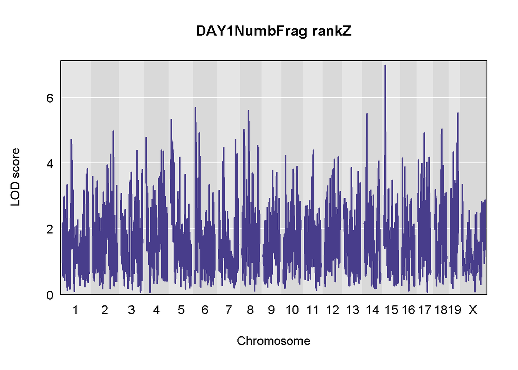

```r
ph  = pheno_rz[,pheno_name, drop = FALSE]
qtl = scan1(genoprobs = probs,
            pheno     = ph,
            kinship   = K,
            addcovar  = addcovar)
plot(qtl, map, main = paste(pheno_name, 'rankZ'))
```

### Total Oocytes

Heritability: 0.36

Gather phenotype and covariates.

```r
pheno_name = 'TotalOocytes'
ph = pheno[,pheno_name, drop = FALSE]

meta_row  = which(meta$column == pheno_name)
transform = meta$transform[meta_row]

if(!is.na(transform)) {
  if(transform == 'log') {
    ph[,1] = log(ph[,1])
  } else if(transform == 'log1p') {
    ph[,1] = log1p(ph[,1])
  } else if(transform == 'sqrt') {
    ph[,1] = sqrt(ph[,1])
  }
} # if(!is.na(transform))

covar_names = strsplit(meta$covar[meta_row], split = ';')[[1]]
addcovar    = model.matrix(~ ., data = covar[,covar_names, drop = FALSE])[,-1, drop = FALSE]
```

Map phenotype with date,NumbClutches as covariates.

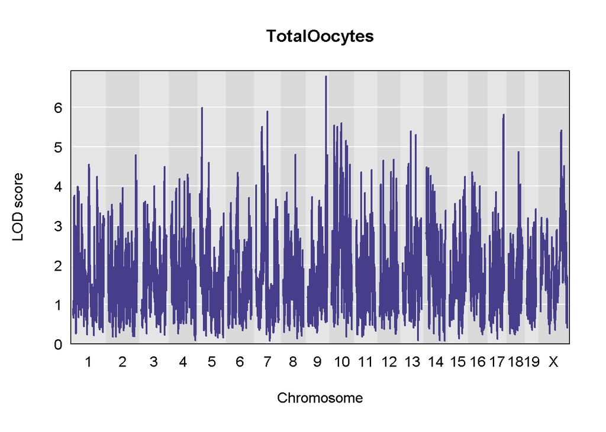

```r
qtl = scan1(genoprobs = probs,
            pheno     = ph,
            kinship   = K,
            addcovar  = addcovar)
plot(qtl, map, main = pheno_name)
```

I don’t see any peaks worth pursuing here.

Map Total Oocytes with date and body weight as covariates.

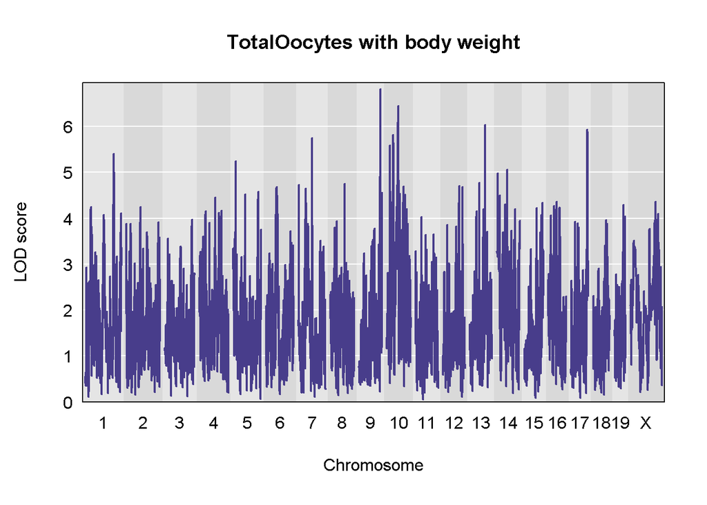

```r
addcovar = model.matrix(~ date, data = covar)[,-1, drop = FALSE]
addcovar = cbind(addcovar, weight = pheno[,'Weight'])

qtl = scan1(genoprobs = probs,
            pheno     = ph,
            kinship   = K,
            addcovar  = addcovar)
plot(qtl, map, main = paste(pheno_name, 'with body weight'))
```

Body weight doesn’t seem to improve the mapping.

Map Total Oocytes with the quantity of RNA isolated from ovaries. This may not make sense since they are strongly correlated. But this may be like mapping number of oocytes, adjusted for ovary size.

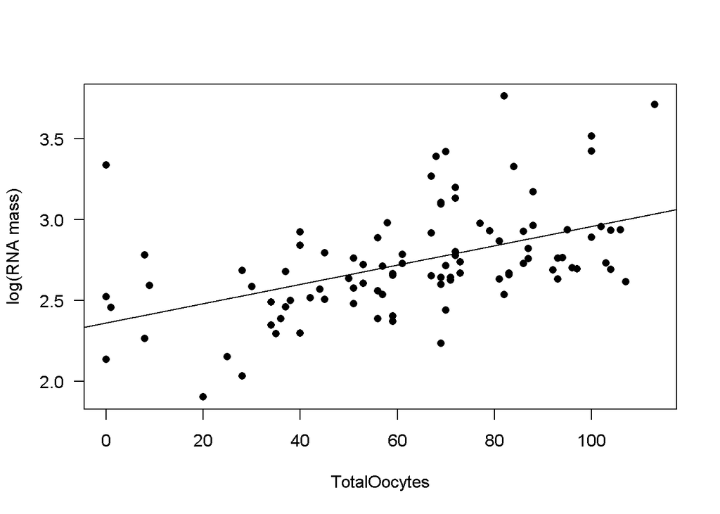

```r
df = merge(pheno, rna, by = 'row.names')
df = df[,c('Row.names', 'TotalOocytes', 'mass')]
df$mass = log(df$mass)

plot(mass ~ TotalOocytes, data = df, las = 1, pch = 16,
     ylab = 'log(RNA mass)')
mod = lm(mass ~ TotalOocytes, data = df)
abline(mod)
```

```r
rm(df)
```

```r
summary(mod)
```

```
##
## Call:
## lm(formula = mass ~ TotalOocytes, data = df)
##
## Residuals:
##      Min       1Q   Median       3Q      Max
## -0.57765 -0.18535 -0.06005  0.15489  0.97680
##
## Coefficients:
##              Estimate Std. Error t value Pr(>|t|)
## (Intercept)  2.361243   0.075354   31.34  < 2e-16 ***
## TotalOocytes 0.005986   0.001094    5.47 3.71e-07 ***
## ---
## Signif. codes:  0 '***' 0.001 '**' 0.01 '*' 0.05 '.' 0.1 ' ' 1
##
## Residual standard error: 0.294 on 94 degrees of freedom
## Multiple R-squared:  0.2414, Adjusted R-squared:  0.2334
## F-statistic: 29.92 on 1 and 94 DF,  p-value: 3.706e-07
```

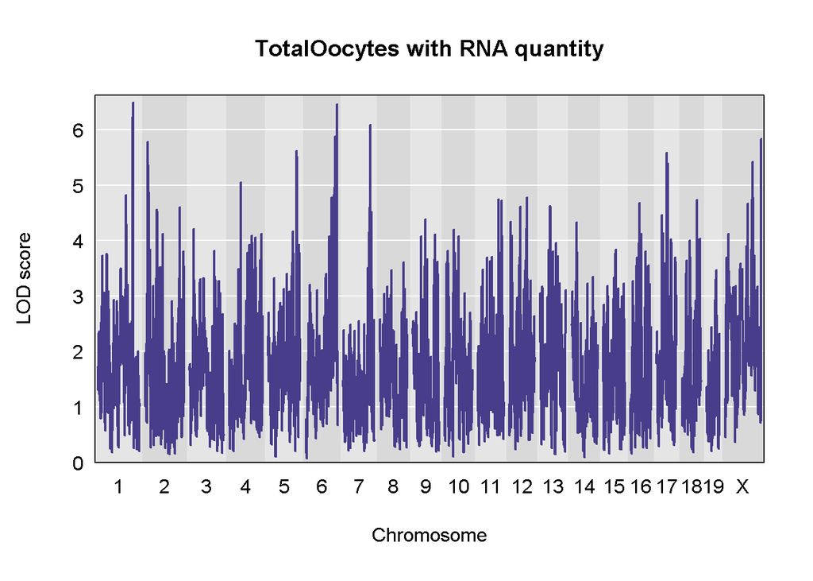

```r
addcovar = model.matrix(~ date + NumbClutches, data = covar)[,-1, drop = FALSE]
addcovar = merge(addcovar, rna, by = 'row.names')
rownames(addcovar) = addcovar$Row.names
addcovar = addcovar[,c(2:8, 11)]

qtl = scan1(genoprobs = probs,
            pheno     = ph,
            kinship   = K,
            addcovar  = addcovar)
plot(qtl, map, main = paste(pheno_name, 'with RNA quantity'))
```

Map rankZ-transformed phenotype with date as a covariate and only samples with two clutches.

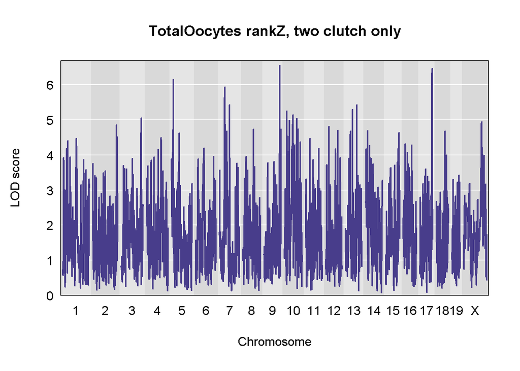

```r
addcovar = model.matrix(~ date, data = covar)[,-1, drop = FALSE]
ph  = pheno_rz[,pheno_name, drop = FALSE]
qtl = scan1(genoprobs = probs[samples,],
            pheno     = ph[samples,,drop = FALSE],
            kinship   = K,
            addcovar  = addcovar[samples,,drop = FALSE])
plot(qtl, map, main = paste(pheno_name, 'rankZ, two clutch only'))
```

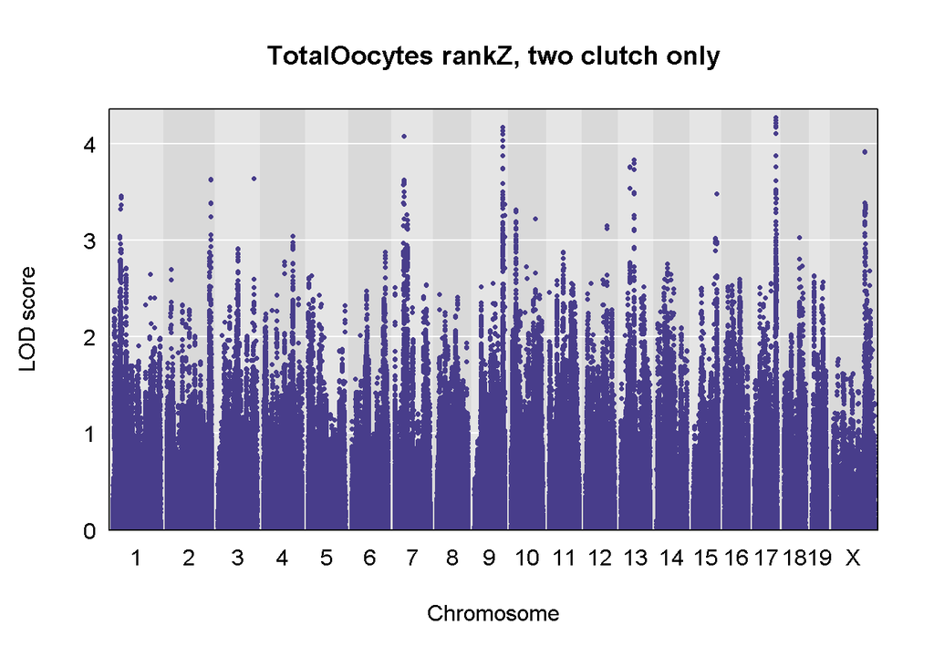

```r
gwas = scan1snps(genoprobs = probs[samples,], map = map, pheno = ph[samples,,drop = FALSE],
                 kinship = K, addcovar = addcovar[samples,,drop = FALSE],
                 query_func = snp_fxn, keep_all_snps = FALSE)
plot_snpasso(gwas$lod, gwas$snpinfo, main = paste(pheno_name,'rankZ, two clutch only'))
```